# GDP Plotting

Now we can summarize all of the work that we have done to plot GDP and its components. Let’s begin with loading the libraries that we will need. Remember that you need to also run the install.packages(“ggplot2”), etc., if theya re not already installed.

```r
library(ggplot2)
library(readr)
library(tidyr)
library(dplyr)

#If you don't have all of these packages, R will revolt.  To install, you can use the following (but remove the comment '#' symbol)
#install.packages("ggplot2")
#install.packages("readr")
#install.packages("tidyr")
#install.packages("")
```

Okay, now we read in the data in the GDP.csv file that we downloaded from the FRED website. After doing that we use the ggplot function to plot it. The syntax of the function is the data set, we use the aes() function to tell it which variable in the data set goes on the x-axis and which goes on the y-axis. Here we are plotting GDP against time. Then we tell it what kind of plot we want: geom_line() tells it to connect each point as a line. Then we add the labels: a title, and what to print on the x-axis and y-axis labels. Finally, I like the theme_bw(), it makes pretty pictures.

```r
gdpData <- read_csv("GDP.csv")
#after downloading from FRED the data file you saved is probably called GDP.csv;

gdpData # This gives me a preview and makes sure that my variable names in the plot below match the dataset
```

| DATE | GDP |
| --- | --- |
| 1947-01-01 | 243.164 |
| 1947-04-01 | 245.968 |
| 1947-07-01 | 249.585 |
| 1947-10-01 | 259.745 |
| 1948-01-01 | 265.742 |
| 1948-04-01 | 272.567 |
| 1948-07-01 | 279.196 |
| 1948-10-01 | 280.366 |
| 1949-01-01 | 275.034 |
| 1949-04-01 | 271.351 |

[output cut: 298 more lines]

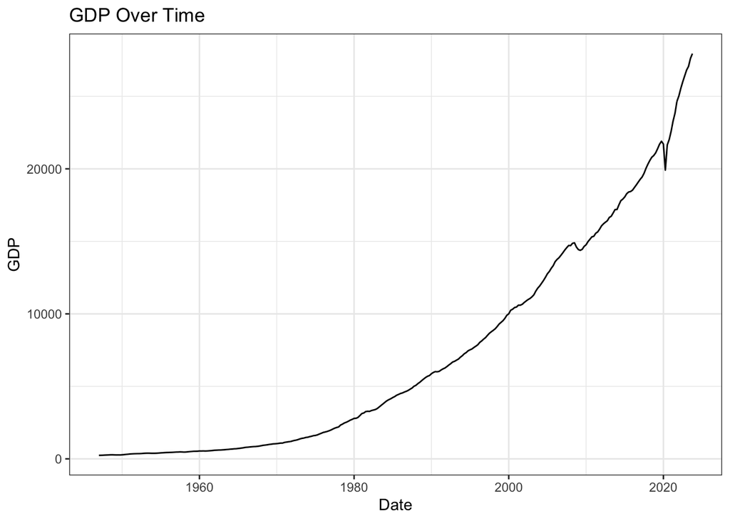

```r
ggplot(data = gdpData, aes(x = DATE, y = GDP)) +
  geom_line() +
  labs(title = "GDP Over Time", x = "Date", y = "GDP") +
  theme_bw()
```

Okay, now that we have a nice looking plot of nominal GDP over time. Let’s plot the components of GDP. We first read in the data that we downloaded from FRED after making a list. Here FRED gives us the choice of downloading as an excel file or a simple text file. It is easier to load a test file outside of excel, so I chose that. Then FRED gives its variables silly names, so let’s put the names into something recognizable. Then we use the pivot command to change the formatting and make it easier to plot each of the variables. Remember what the text said: we asked ChatGPT how to do this.

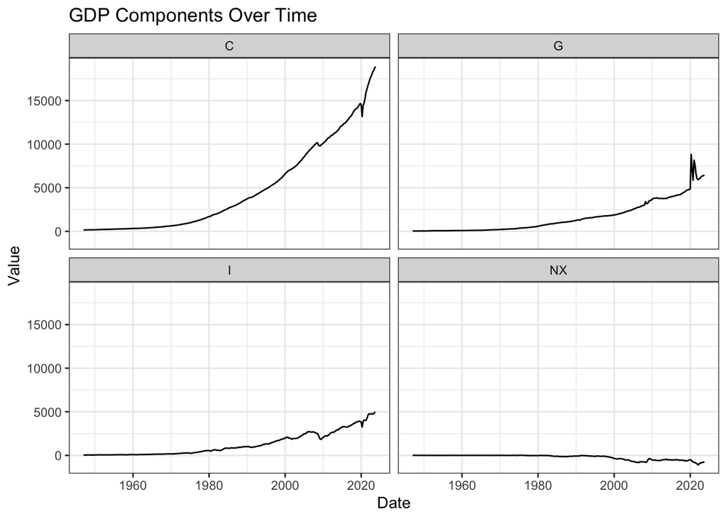

```r
# Now plot the GDP components


GDPcomponents <- read_tsv("GDP_components_Quarterly.txt") # I saved it as a text file and used read_tsv to open text;

# Change the FRED's silly names for the names we use in the book, C,I,G,NX
GDPcomponents <- GDPcomponents %>%
  rename(
    G = FGEXPND,
    I = GPDI,
    NX = NETEXP,
    C = PCEC
  )
# Pivot the data to a long format -- If you type 'GDPcomponents_long' into the console you can see what this command does.
GDPcomponents_long <- GDPcomponents %>%
  pivot_longer(cols = c(G, I, NX, C), names_to = "Variable", values_to = "Value")

# Plot the data
plotComponents <- ggplot(GDPcomponents_long, aes(x = DATE, y = Value)) + geom_line() + # Draw lines
  facet_wrap(~Variable, ncol = 2) + # Create a 2 by 2 grid of plots based on the variable
labs(title = "GDP Components Over Time", x = "Date", y = "Value") +
  theme_bw() # Use a minimal theme for a clean look
plotComponents
```

```r
# Save the plot as a JPEG file
ggsave("GDPcomponents.jpeg", plot = plotComponents, width = 8, height = 6, dpi
       = 300)
```

The last thing for us to do is to plot real GDP and real GDP per capita. Here, I want to show you why R is better than using excel. With R, we can use a library called `fredr` that allows us to interact directly with the FRED server using something called an API. We load the library, and then we have to define the FRED API key. How do we know the FRED API key? Go to your account in FRED, select the section related to API keys. Then set up a new key, giving it an easy to remember name. Then you just cut and paste it into the `fredr_set_key()` function. Then all you need to know is the series_id. When you search for a variable, say `real GDP`, FRED will plot the data for you, and at the top in parentheses it will give you the series_id. You can just cut and paste it. You can also ask ChatGPT who knows all of the series_id’s.

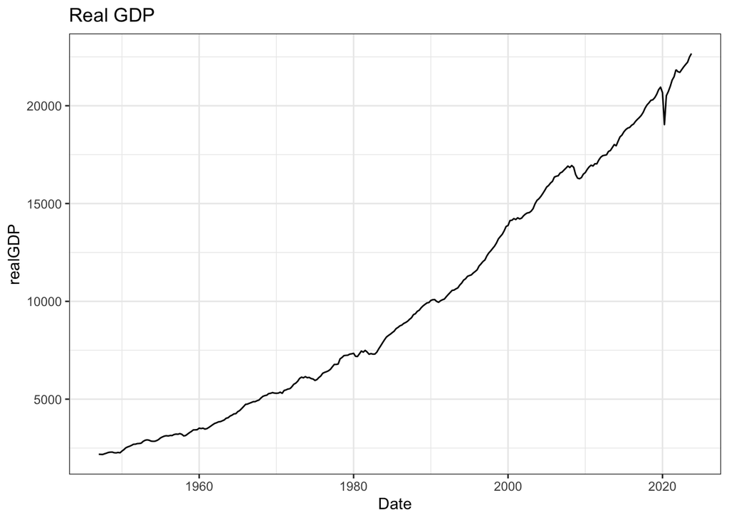

```r
# We can also use a package that can interact directly with FRED rather than going and downloading on our own.
library(fredr)
fredr_set_key('1eb4018cc8ead6ac6445763becf7bf42')

realGDP <- fredr(series_id = "GDPc1")
realGDPperCapita <- fredr(series_id = "A939RX0Q048SBEA")

p1 <- ggplot(realGDP, aes(x = date, y = value )) +
  geom_line() +
  labs(title = "Real GDP", x = "Date", y = "realGDP") +
  theme_bw()
p1
```

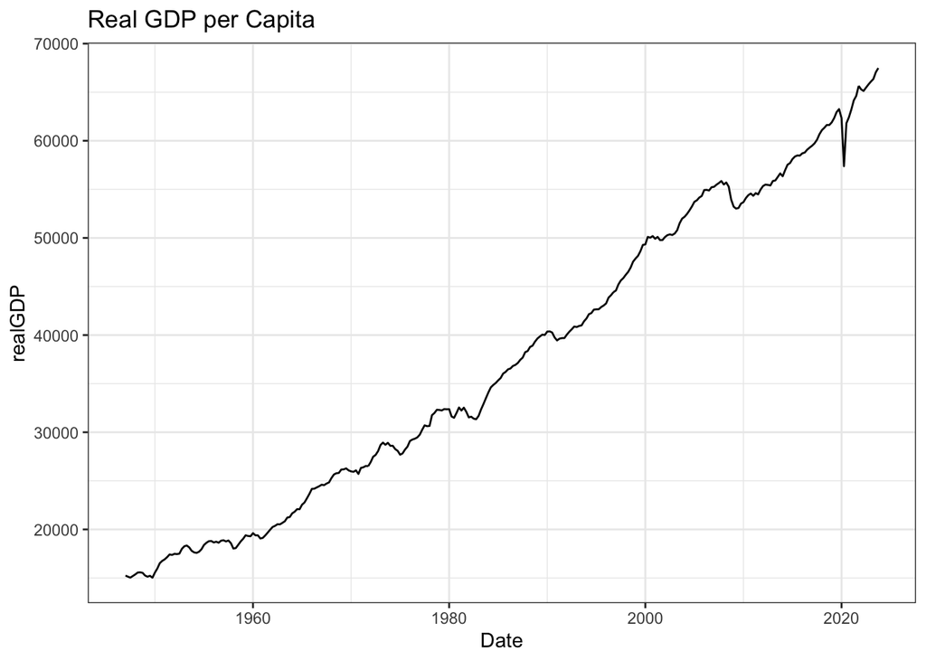

```r
p2 <- ggplot(realGDPperCapita, aes(x = date, y = value )) +
  geom_line() +
  labs(title = "Real GDP per Capita", x = "Date", y = "realGDP") +
  theme_bw()
p2
```

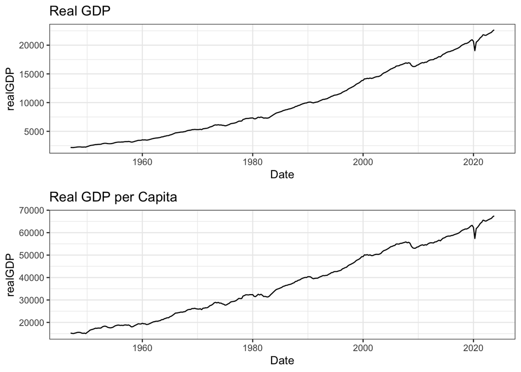

```r
# If you want to layout the plots in a grid can also do it like this using the gridExtra package:
library(gridExtra) # install.packages("gridExtra") if it is your first time.
grid.arrange(p1, p2, nrow = 2)
```

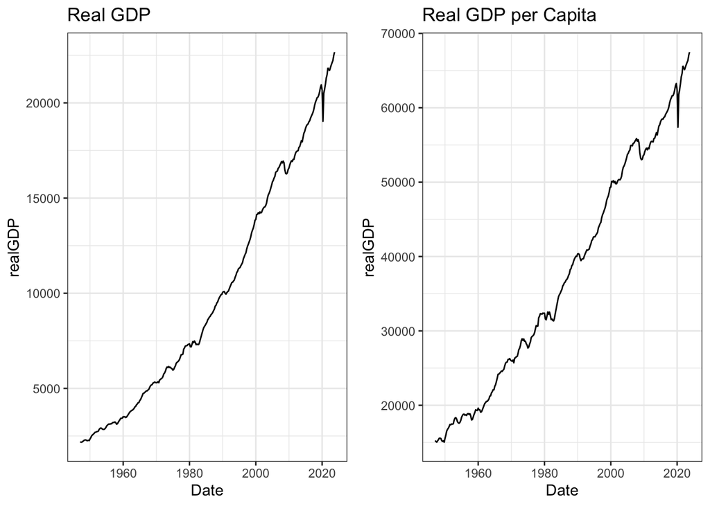

```r
#or
grid.arrange(p1, p2, ncol = 2)
```